# Machine Predictive Maintenance Classification

2024-03-25

# Introduction

Predictive machine maintenance is vital in the future of manufacturing because it allows for timely repairs to machines before failures occur. In this project, I will demonstrate how common machine learning algorithms, such as decision trees and support vector machines, can be used in machine maintenance. Predictive maintenance is key in monitoring equipment and their conditions to more accurately predict when and what maintenance should be performed. This utilization of information can assist in minimizing downtime, optimize resource allocation, and most importantly reduce maintenance costs. The main idea is to implement past maintenance data to predict equipment failures before those failures occur.

Predictive maintenance is important in multiple practical ways, such as allowing companies to schedule routine maintenance more accurately, avoid unwarranted delays, as well as extending the duration of use of the machines. It is also important in theoretical ways. For example, it can also lead to interesting breakthroughs in terms of data mining and machine learning techniques. It does this by forcing the analyses of multiple volumes of data, which can be unbalanced or even have missing values, which can then be utilized to develop predictive models.

One of the primary challenges is the minimal amount of research previously done that addresses domain-specific issues and provides solutions to those issues. While it has been studied to an extensive degree, there are still important needs that should address specific characteristics for varying industries while also attempting to improve predictive accuracy amongst the models.

## Preliminary Data Analysis

### Outline

- Data Types of Variables
- Steps for cleaning
  - What variables are missing
  - Outliers
- Descriptive and Statistical Inference of the Data
  - Data Summary
  - Correlation Analysis

### Data Types of Variables

```r
for (column in colnames(maintenance)){
  cat("The type of", column, "is",  typeof(column),"\n")
  cat("\n")
}
```

```
## The type of UDI is character
##
## The type of Product.ID is character
##
## The type of Type is character
##
## The type of Air.temperature..K. is character
##
## The type of Process.temperature..K. is character
##
## The type of Rotational.speed..rpm. is character
##
## The type of Torque..Nm. is character
##
## The type of Tool.wear..min. is character
##
## The type of Target is character
##
## The type of Failure.Type is character
```

### Descriptive and Statistical Inference of the Data

#### Summary

```r
summary(maintenance)
```

```
##       UDI         Product.ID            Type           Air.temperature..K.
##  Min.   :    1   Length:10000       Length:10000       Min.   :295.3
##  1st Qu.: 2501   Class :character   Class :character   1st Qu.:298.3
##  Median : 5000   Mode  :character   Mode  :character   Median :300.1
##  Mean   : 5000                                         Mean   :300.0
##  3rd Qu.: 7500                                         3rd Qu.:301.5
##  Max.   :10000                                         Max.   :304.5
##  Process.temperature..K. Rotational.speed..rpm.  Torque..Nm.    Tool.wear..min.
##  Min.   :305.7           Min.   :1168           Min.   : 3.80   Min.   :  0
##  1st Qu.:308.8           1st Qu.:1423           1st Qu.:33.20   1st Qu.: 53
##  Median :310.1           Median :1503           Median :40.10   Median :108
##  Mean   :310.0           Mean   :1539           Mean   :39.99   Mean   :108
##  3rd Qu.:311.1           3rd Qu.:1612           3rd Qu.:46.80   3rd Qu.:162
##  Max.   :313.8           Max.   :2886           Max.   :76.60   Max.   :253
##      Target       Failure.Type
##  Min.   :0.0000   Length:10000
##  1st Qu.:0.0000   Class :character
##  Median :0.0000   Mode  :character
##  Mean   :0.0339
##  3rd Qu.:0.0000
##  Max.   :1.0000
```

### Steps for Cleaning

#### Missing data

The following segment checks to see if there are any missing variables in the data set.

```r
# find location of missing values
cat("Position of missing values ")
```

```
## Position of missing values
```

```r
which(is.na(maintenance))
```

```
## integer(0)
```

```r
# count total missing values
cat("Count of total missing values  ")
```

```
## Count of total missing values
```

```r
sum(is.na(maintenance))
```

```
## [1] 0
```

There are not any missing values in the data set

#### Structure Errors

There are some structural errors that need to be cleaned like the data types, and some of the columns might need to be renamed.

#### Outliers

```r
print_outliers <- function(col){

  lowerbound <- quantile(col,.025)
  upperbound <- quantile(col, .975 )

  #Counts outliers
  outliers <- length(which(col < lowerbound | col > upperbound))

  #Prints
  if(length(outliers) == 0){
      outliers = "None"
  }
  cat("The number of outliers is", outliers, "\n")
}
cat("\nRotational Speed \n")
```

```
##
## Rotational Speed
```

```r
print_outliers(maintenance$Rotational.speed..rpm.)
```

```
## The number of outliers is 493
```

```r
cat("\nTorque \n")
```

```
##
## Torque
```

```r
print_outliers(maintenance$Torque..Nm.)
```

```
## The number of outliers is 499
```

```r
cat("\nTool Wear \n")
```

```
##
## Tool Wear
```

```r
print_outliers(maintenance$Tool.wear..min.)
```

```
## The number of outliers is 438
```

There are outliers in the data set and they will need to be dealt with by either making a linear regression, ignoring them, or removing them from the data set.

```r
# Rename columns
colnames(maintenance) <- c('udi','prod_id','type','air_temp','process_temp','rotational_speed','torque','tool_wear','target','failure_typ')
```

#### Correlation Analysis

```r
library(corrplot)
```

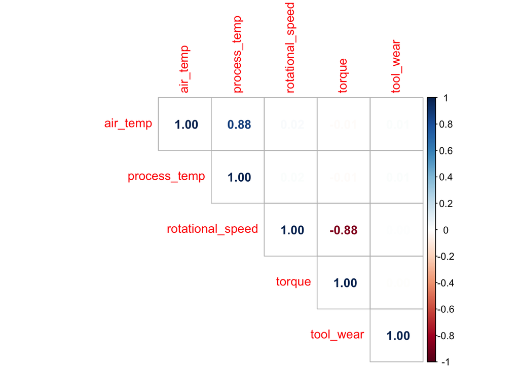

```r
# Correlation analysis plot
corrplot(cor(maintenance[,c('air_temp','process_temp','rotational_speed','torque','tool_wear')]), method = 'number', type = 'upper')
```

There is a strong correlation between Process Temperate and Air Temperature, as well as, Rotational Speed and Torque. This could cause issues when fitting predictive models.

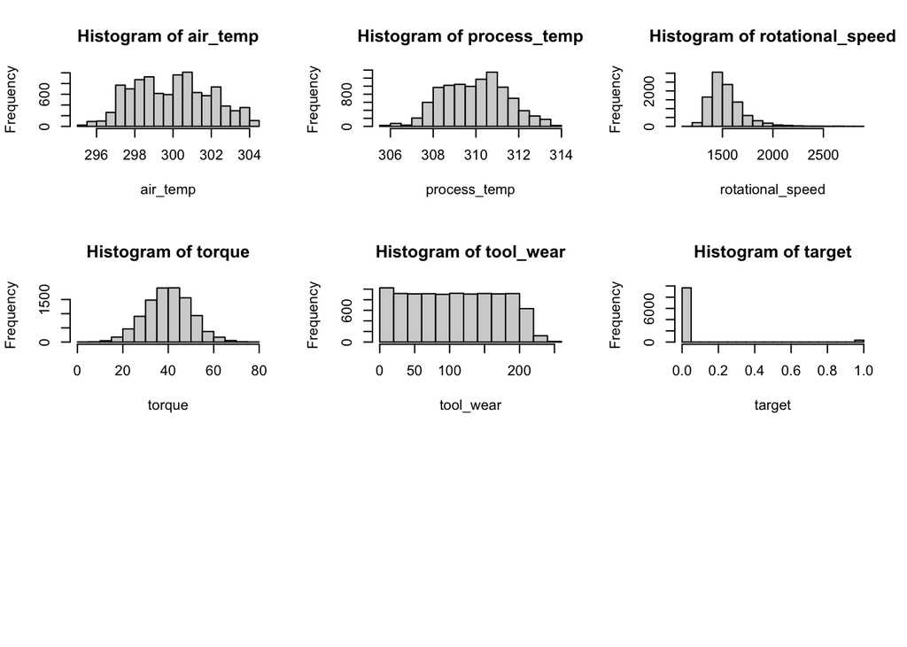

```r
# Plot histograms
num_cols <- sapply(maintenance, is.numeric) & colnames(maintenance) != "udi"
num_count <- sum(num_cols)
par(mfrow=c(ceiling(sqrt(num_count)), ceiling(sqrt(num_count))))
for (col in colnames(maintenance)[num_cols]) {
  hist(maintenance[[col]], main=paste('Histogram of', col), xlab=col)
}
```

Because rotational speed is skewed, we need to transform

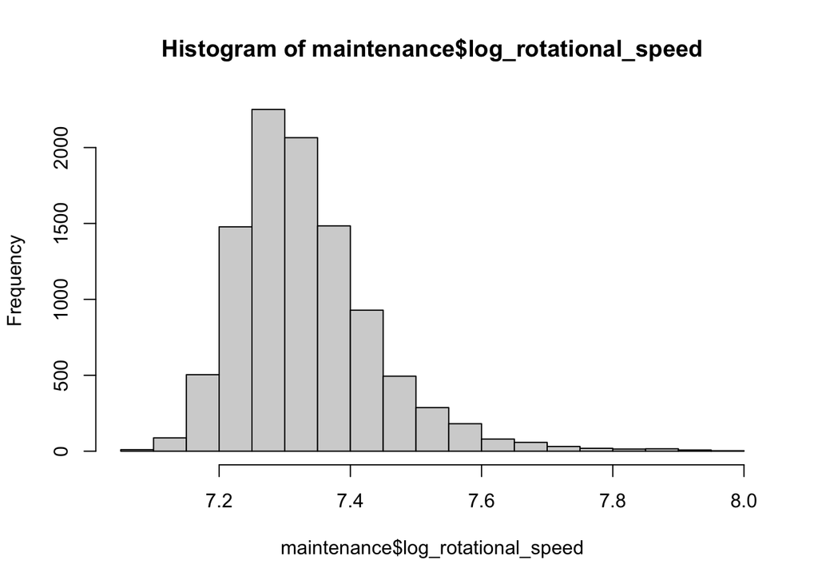

```r
# Apply log transformation to 'rotational_speed'
maintenance$log_rotational_speed <- log(maintenance$rotational_speed)
hist(maintenance$log_rotational_speed)
```

#### Encoding Categorical Variables

```r
# Making predictor variable a factor
maintenance$target <- as.factor(maintenance$target)
maintenance$type <- factor(maintenance$type)
maintenance$failure_typ <- factor(maintenance$failure_typ)
```

## Methods

```r
# Splitting data into training and testing sets
set.seed(1)
index <- sample(c(T, F), nrow(maintenance), replace = T, prob = c(0.7, 0.3))
train <- maintenance[index,]
test <- maintenance[!index,]
```

```r
library(lattice)
library(caret)
library(pROC)
```

```r
# Multiple Linear Regression
lm_multi<-glm(target~type+torque+log_rotational_speed+air_temp+process_temp+tool_wear, data=train, family = 'binomial')
```

```r
summary(lm_multi)
```

```
##
## Call:
## glm(formula = target ~ type + torque + log_rotational_speed +
##     air_temp + process_temp + tool_wear, family = "binomial",
##     data = train)
##
## Coefficients:
##                        Estimate Std. Error z value Pr(>|z|)
## (Intercept)          -1.708e+02  2.057e+01  -8.306  < 2e-16 ***
## typeL                 6.810e-01  3.285e-01   2.073   0.0382 *
## typeM                 4.447e-01  3.468e-01   1.282   0.1997
## torque                2.699e-01  1.534e-02  17.593  < 2e-16 ***
## log_rotational_speed  1.926e+01  1.388e+00  13.869  < 2e-16 ***
## air_temp              7.636e-01  8.521e-02   8.961  < 2e-16 ***
## process_temp         -6.996e-01  1.127e-01  -6.206 5.45e-10 ***
## tool_wear             1.312e-02  1.346e-03   9.742  < 2e-16 ***
## ---
## Signif. codes:  0 '***' 0.001 '**' 0.01 '*' 0.05 '.' 0.1 ' ' 1
##
## (Dispersion parameter for binomial family taken to be 1)
##
##     Null deviance: 1980.4  on 6963  degrees of freedom
## Residual deviance: 1396.4  on 6956  degrees of freedom
## AIC: 1412.4
##
## Number of Fisher Scoring iterations: 7
```

### Logistic Regression

```r
library(tidyverse)
```

```r
# Logistic regression predictions
probs <- lm_multi %>% predict(test, type = 'response')
glm.pred <- ifelse(probs > 0.5, 1, 0)
glm.pred <- as.factor(glm.pred)
```

```r
# Logistic regression confusion matrix
glm.conf <- confusionMatrix(test$target, glm.pred)
glm.conf
```

```
## Confusion Matrix and Statistics
##
##           Reference
## Prediction    0    1
##          0 2913    8
##          1   97   18
##
##                Accuracy : 0.9654
##                  95% CI : (0.9583, 0.9716)
##     No Information Rate : 0.9914
##     P-Value [Acc > NIR] : 1
##
##                   Kappa : 0.2448
##
##  Mcnemar's Test P-Value : <2e-16
##
##             Sensitivity : 0.9678
##             Specificity : 0.6923
##          Pos Pred Value : 0.9973
##          Neg Pred Value : 0.1565
##              Prevalence : 0.9914
##          Detection Rate : 0.9595
##    Detection Prevalence : 0.9621
##       Balanced Accuracy : 0.8300
##
##        'Positive' Class : 0
##
```

```r
# ROC chart for logistic regression model
roc.glm <- pROC::multiclass.roc(glm.pred, as.numeric(test$target))
```

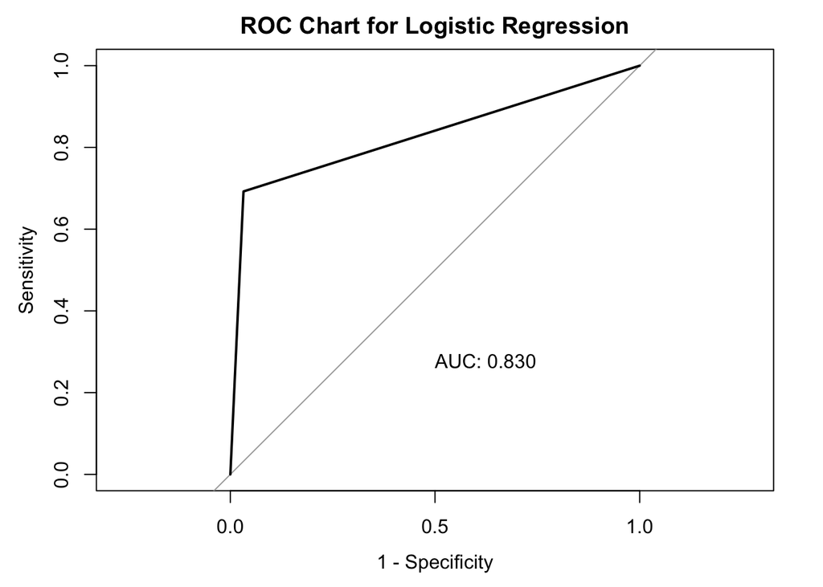

```r
plot(roc.glm$rocs[[1]], print.auc=T,legacy.axes=T, print.auc.adj = c(0,7),main = 'ROC Chart for Logistic Regression')
```

### Random Forest

```r
# Random Forest
library(randomForest)
```

```r
rf <- randomForest(target ~ type+torque+log_rotational_speed+air_temp+process_temp+tool_wear, train)
```

```r
rf.pred <- predict(rf, test)
```

```r
# Confusion Matrix for random forest model
cm <- table(test$target, rf.pred)
rf.conf <- confusionMatrix(cm)
rf.conf
```

```
## Confusion Matrix and Statistics
##
##    rf.pred
##        0    1
##   0 2914    7
##   1   49   66
##
##                Accuracy : 0.9816
##                  95% CI : (0.9761, 0.986)
##     No Information Rate : 0.976
##     P-Value [Acc > NIR] : 0.02196
##
##                   Kappa : 0.6931
##
##  Mcnemar's Test P-Value : 4.281e-08
##
##             Sensitivity : 0.9835
##             Specificity : 0.9041
##          Pos Pred Value : 0.9976
##          Neg Pred Value : 0.5739
##              Prevalence : 0.9760
##          Detection Rate : 0.9598
##    Detection Prevalence : 0.9621
##       Balanced Accuracy : 0.9438
##
##        'Positive' Class : 0
##
```

```r
# ROC chart for random forest model
roc.rf <- pROC::multiclass.roc(rf.pred, as.numeric(test$target))
```

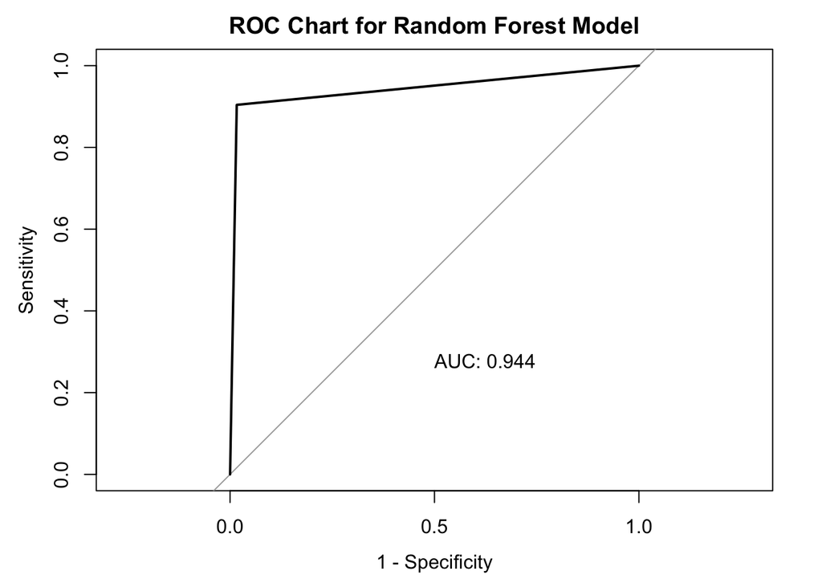

```r
plot(roc.rf$rocs[[1]], print.auc=T,legacy.axes=T, print.auc.adj = c(0,7),main = 'ROC Chart for Random Forest Model')
```

### Decision Tree

```r
library(tree)
library(ISLR2)
#Decision Tree

#Regular Decision Tree
dt <- tree(target ~ type+torque+log_rotational_speed+air_temp+process_temp+tool_wear,
           train)
dt.pred <- predict(dt,test, type = "class")
cm <- table(test$target,dt.pred)
dt.conf <- confusionMatrix(cm)
dt.conf
```

```
## Confusion Matrix and Statistics
##
##    dt.pred
##        0    1
##   0 2909   12
##   1   62   53
##
##                Accuracy : 0.9756
##                  95% CI : (0.9695, 0.9808)
##     No Information Rate : 0.9786
##     P-Value [Acc > NIR] : 0.8818
##
##                   Kappa : 0.5773
##
##  Mcnemar's Test P-Value : 1.226e-08
##
##             Sensitivity : 0.9791
##             Specificity : 0.8154
##          Pos Pred Value : 0.9959
##          Neg Pred Value : 0.4609
##              Prevalence : 0.9786
##          Detection Rate : 0.9582
##    Detection Prevalence : 0.9621
##       Balanced Accuracy : 0.8973
##
##        'Positive' Class : 0
##
```

```r
#Pruning
prune.dt <- prune.misclass(dt, best=14)

prune.dt.pred <- predict(prune.dt,test, type = "class")
cm <- table(test$target,prune.dt.pred)
prune.dt.conf <- confusionMatrix(cm)
prune.dt.conf
```

```
## Confusion Matrix and Statistics
##
##    prune.dt.pred
##        0    1
##   0 2909   12
##   1   62   53
##
##                Accuracy : 0.9756
##                  95% CI : (0.9695, 0.9808)
##     No Information Rate : 0.9786
##     P-Value [Acc > NIR] : 0.8818
##
##                   Kappa : 0.5773
##
##  Mcnemar's Test P-Value : 1.226e-08
##
##             Sensitivity : 0.9791
##             Specificity : 0.8154
##          Pos Pred Value : 0.9959
##          Neg Pred Value : 0.4609
##              Prevalence : 0.9786
##          Detection Rate : 0.9582
##    Detection Prevalence : 0.9621
##       Balanced Accuracy : 0.8973
##
##        'Positive' Class : 0
##
```

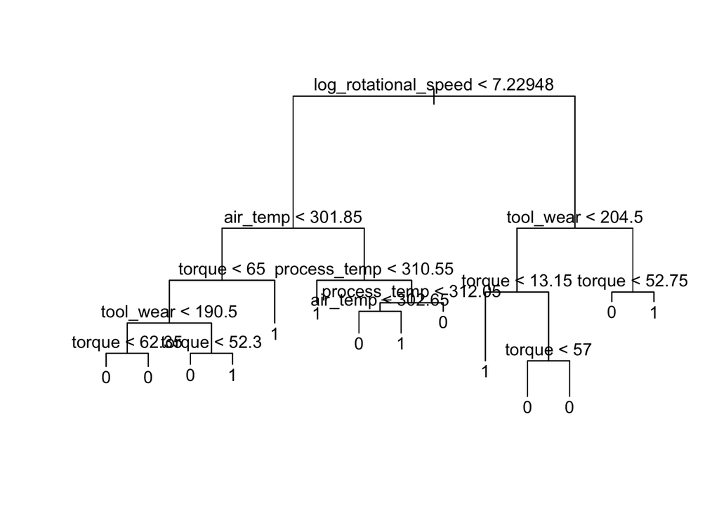

```r
#Plotting
plot(prune.dt)
text(prune.dt,pretty=0)
```

```r
# ROC chart for random forest model
roc.dt <- pROC::multiclass.roc(prune.dt.pred, as.numeric(test$target))
```

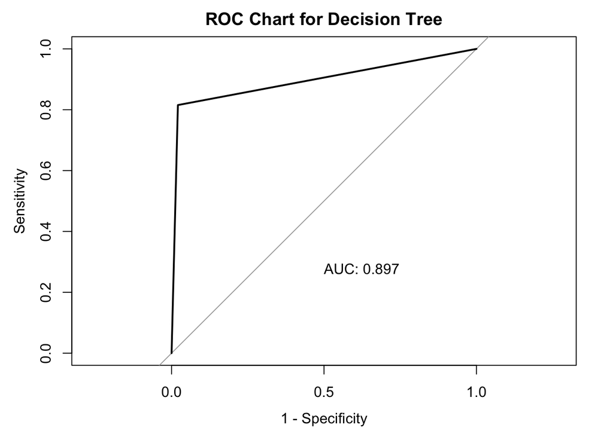

```r
plot(roc.dt$rocs[[1]], print.auc=T,legacy.axes=T, print.auc.adj = c(0,7),main = 'ROC Chart for Decision Tree')
```

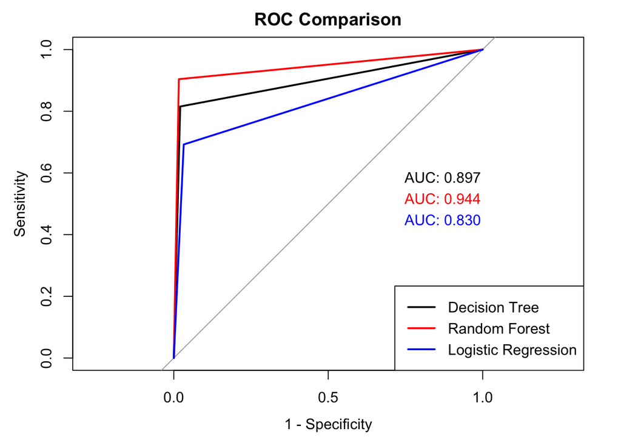

```r
# ROC comparison chart
plot(roc.dt$rocs[[1]], print.auc=T,legacy.axes=T, print.auc.adj = c(-1,-2),main = 'ROC Comparison')

plot(roc.rf$rocs[[1]], add=T, col='red', print.auc=T,legacy.axes=T, print.auc.adj = c(-1,0))

plot(roc.glm$rocs[[1]], add=T, col='blue', print.auc=T,legacy.axes=T, print.auc.adj = c(-1,2))

legend('bottomright', legend = c('Decision Tree', 'Random Forest', 'Logistic Regression'), col=c('black','red','blue'),lwd=2)
```

### SVM

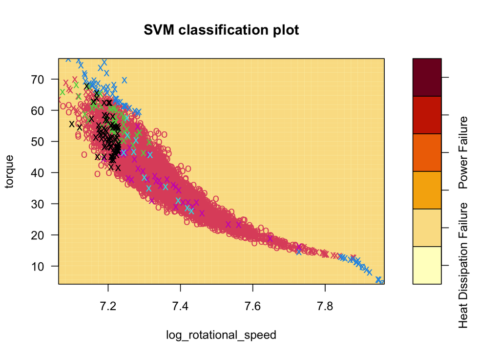

```r
#Clustering
library(e1071)
View(maintenance)
maintenance$failure_typ <- as.integer(factor(maintenance$failure_typ))
View(maintenance)
svm.fit <- svm(failure_typ ~ type+torque+log_rotational_speed+air_temp+process_temp+tool_wear, train, kernel = "radial" )

#Plotting
plot(svm.fit, train,torque ~ log_rotational_speed, main= "Torque vs. Rotational Speed SVM Classification Plot" )
```

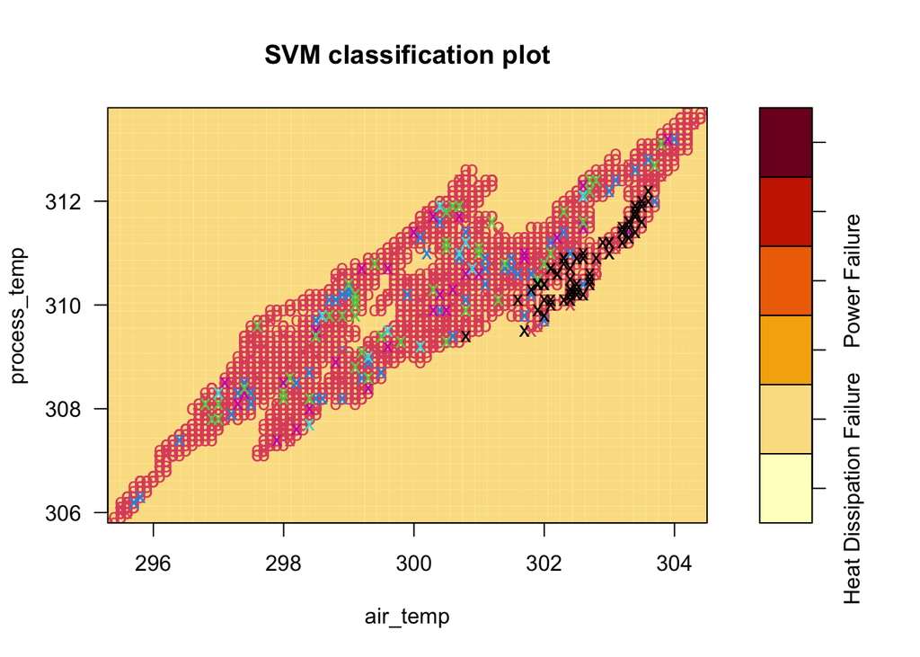

```r
plot(svm.fit, train, process_temp ~ air_temp, main = "Process Temperature vs. Process Temperature SVM Classification Plot" )
```

```r
#Getting the accuracy
svm.pred <- predict(svm.fit,test, type = "class")
cm <- table(test$failure_typ,svm.pred)
svm.conf <- confusionMatrix(cm)
svm.conf
```

```
## Confusion Matrix and Statistics
##
##                           svm.pred
##                            Heat Dissipation Failure No Failure
##   Heat Dissipation Failure                        0         36
##   No Failure                                      0       2917
##   Overstrain Failure                              0         23
##   Power Failure                                   0         20
##   Random Failures                                 0          6
##   Tool Wear Failure                               0         11
##                           svm.pred
##                            Overstrain Failure Power Failure Random Failures
##   Heat Dissipation Failure                  1             0               0
##   No Failure                                0             1               0
##   Overstrain Failure                        5             0               0
##   Power Failure                             5            11               0
##   Random Failures                           0             0               0
##   Tool Wear Failure                         0             0               0
##                           svm.pred
##                            Tool Wear Failure
##   Heat Dissipation Failure                 0
##   No Failure                               0
##   Overstrain Failure                       0
##   Power Failure                            0
##   Random Failures                          0
##   Tool Wear Failure                        0
##
## Overall Statistics
##
##                Accuracy : 0.9661
##                  95% CI : (0.959, 0.9722)
##     No Information Rate : 0.9924
##     P-Value [Acc > NIR] : 1
##
##                   Kappa : 0.2636
##
##  Mcnemar's Test P-Value : NA
##
## Statistics by Class:
##
```

[output cut: 12 more lines]

```
## Pos Pred Value                        0.178571             0.305556
## Neg Pred Value                        0.998005             0.999667
## Prevalence                            0.003623             0.003953
## Detection Rate                        0.001647             0.003623
## Detection Prevalence                  0.009223             0.011858
## Balanced Accuracy                     0.723471             0.954200
##                      Class: Random Failures Class: Tool Wear Failure
## Sensitivity                              NA                       NA
## Specificity                        0.998024                 0.996377
## Pos Pred Value                           NA                       NA
## Neg Pred Value                           NA                       NA
## Prevalence                         0.000000                 0.000000
## Detection Rate                     0.000000                 0.000000
## Detection Prevalence               0.001976                 0.003623
## Balanced Accuracy                        NA                       NA
```

# Conclusion

It was found that the random forest model was the optimal choice in determining predictive maintenance due to its versatility in usage. It can be applied to both classification and regression tasks as well as its high accuracy in determining predictions and variations. Since there were thousands of data points in the study, random forest also helps alleviate some of that noise level due to its input subletting capabilities.

Looking into considerations or changes that we would implement for future projects, we would try to get actual data points from machining factories to be able to more accurately determine failure rates in real world scenarios. These are difficult to come by however, due to the exclusivity of this data to prevent competition from obtaining and copying the machining process being used by that specific company.